# 01_Introduction to Linear Regression

## 1. The linear model

Linear regression is an approach for modelling the relationship between a scalar *response* - also referred to as the *dependent* or *target variable* - typically denoted by $y$, and one or more explanatory variables, namely the *regressors* - or *covariates*, *independent variables*, *predictors* - given in a matrix $\mathbf{X} \in \mathbb{R}^{n \times p}$. In particular, such a relationship is assumed to be **linear** in the parameters of the equation, although some of the regressors might not be linear.

The case of one explanatory variable (i.e. $p = 1$) is called **simple linear regression**; for more than one ($p \geq 2$), it is called **multiple linear regression**.

The general setup consists of the target variable $y$ and design matrix $\mathbf{X}$, whose relationship is modelled as

$$y = X \beta + \varepsilon$$

where $\varepsilon$ is an error term which is assumed to have a Gaussian distribution with $0$-mean and variance $\sigma^2$. By the properties of the Gaussian density, it follows that $y$ is also normally distributed with mean $\mathbf{X}\beta$ and variance depending on the variance of the error term, i.e. $\sigma^2$. For this reason, this is commonly called the **Gaussian linear regression model**. We will consider such a framework also for Bayesian regression.

### *Example 1: modeling a generic curve*

Despite its simplicity, linear regression can be a powerful way to approximate many functions using real data. We consider the following Data Generating Process (DGP), namely a rule describing how the data were generated, given by

$$y = 1+0.85x^2+1.75\log x + \varepsilon, \qquad \text{ for } x \in [1,10]$$
where $\varepsilon \sim \mathscr{N}(0,50)$ is the error term, also called *noise* or *disturbance*, because we usually collect data that are subject to measurement error.

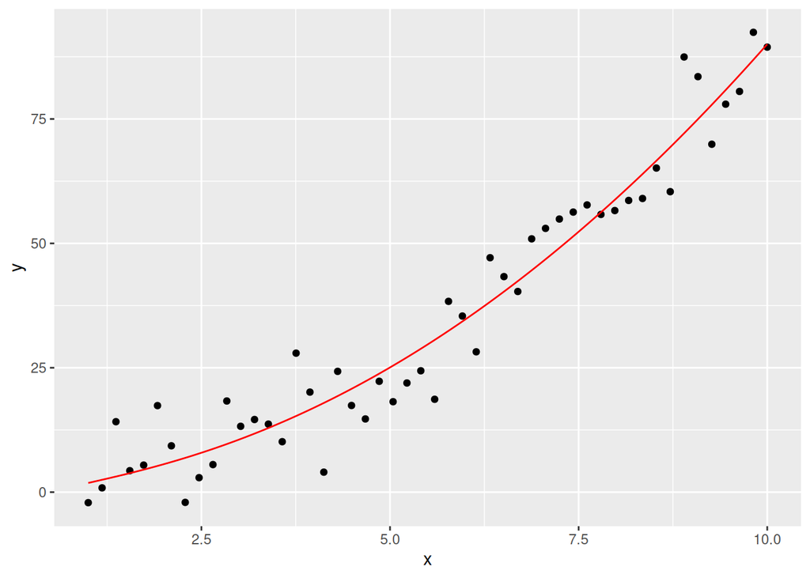

```r
# Clear the workspace
rm(list=ls())

set.seed(123)

# pyplot-like plots in R
library("ggplot2")

# Generate data
n = 50
sigma2 = 50
e = rnorm(n,0,sigma2^0.5)
x = seq(1,10,length.out=n)
y = 1+0.85*x^2+1.75*log(x) + e
data = data.frame(x,y)

f = function(x){
  1 + 0.85*x^2+1.75*log(x)
}

# Plot
g1 = ggplot(data=data, aes(x=x,y=y)) +
  geom_point() +
  geom_function(fun=f, col="red")
g1
```

The simulated data are spread around the true function, and not exactly equal to it, because of the noise component. You may change the variance of $\varepsilon$ to increase or decrease the variability of the dependent variable $y$.

As an introduction to Bayesian linear regression, we consider a conjugate model where the variance $\sigma^2$ is known. The model setup is

$$\begin{align*}
(y_1,\dots,y_n) \mid \beta &\sim \mathscr{N}_{n}\left(\,
\mathbf{X}\beta, \sigma^2\mathbf{I}_{n} \,\right) \\
\beta &\sim \mathscr{N}_{p}\left(\, \mu_{0}, \tau^2\mathbf{I}_{p}
\,\right)
\end{align*}$$

where $\mathbf{X} \in \mathbb{R}^{n \times p}$ collects the covariates used to explain the responses $\left( y_1, \dots, y_n \right)$. However, to kick-start we consider a simple linear regression where

$$\mathbf{X}
=
\begin{bmatrix}
1 & x_1 \\
1 & x_2 \\
\vdots & \vdots \\
1 & x_n
\end{bmatrix}$$
where the explanatory variable $(x_1,\ldots,x_n)$ was denoted by `x` in the chunk of code above, and is simply the range of values in the interval $[1,10]$. Notice that we include an intercept term (the column of ones), otherwise we force the regression line to pass through the origin.

One may check that the posterior distribution is $\beta \mid \mathbf{y} \sim \mathscr{N}_{p}\left(\mu_n, S_n\right)$, where the parameters are defined as

$$\begin{align*}
S_n &= \left(S_0^{-1} +
\mathbf{X}^T\mathbf{X}/\sigma^2\right)^{-1} &\qquad \mu_n &=
S_n\left(S_0^{-1}\mu_0 + \mathbf{X}^T\mathbf{y}/\sigma^2\right)
\end{align*}$$

Since we are interested in reconstructing the curve from the data points, we need the predictive distribution $\widehat{y}_i \mid \mathbf{y},\mathbf{X}$, for which a closed expression is available. For a generic row vector $x_i^T$ of the design matrix,

$$\widehat{y}_i \mid \mathbf{y},\mathbf{X} \sim
\mathscr{N}\left(x_i^T\mu_n, \sigma^2 + x_i^TS_nx_i\right).$$

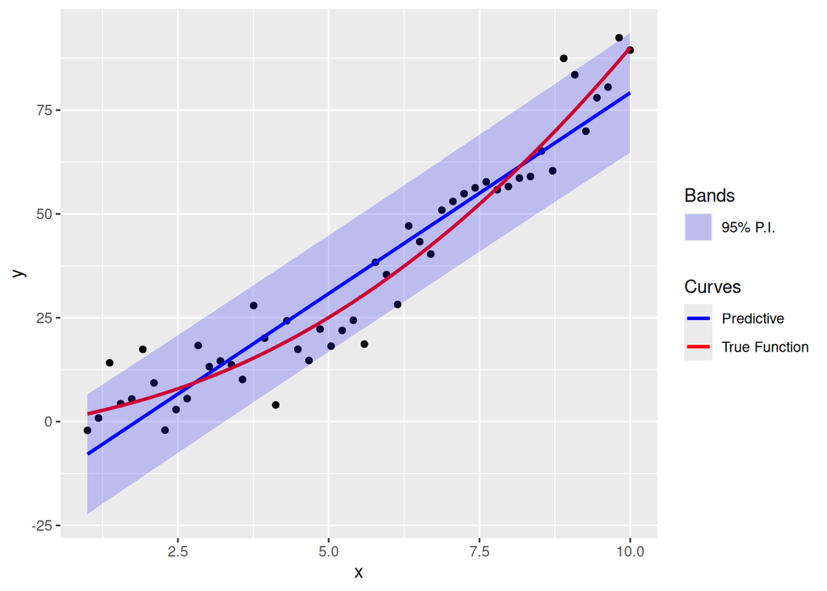

```r
# Construct the design matrix
p = 2
X = matrix(c(rep(1,n),x),n,p)

# Prior hyperparameters (non-informative)
m0 = matrix(0,p,1) # mu0 is the zero vector
S0 = diag(x=1000,p,p) # tau^2=1000

# Posterior parameters
SN = solve(solve(S0) + t(X) %*% X/sigma2) # `solve()` computes the inverse
mN = SN %*% (solve(S0) %*% m0 + t(X) %*% y/sigma2)

# Predictive distribution in the same points
y_hat = t(mN) %*% t(X)
sigma2_hat = array(0, n)
for(i in 1:n){
 sigma2_hat[i] = sigma2 + X[i,] %*% SN %*% X[i,]
}

# Plot
g_bayes = g1 +
  geom_line(aes(x=x,y=y_hat[1,], color="Predictive"), linewidth=1) +
  geom_function(aes(color="True Function"), fun = f, linewidth=1) +
  geom_ribbon(aes(x=x,y=y_hat[1,],
                  ymin=y_hat[1,]-1.96*sigma2_hat^0.5,
                  ymax=y_hat[1,]+1.96*sigma2_hat^0.5,
                  fill="95% P.I."), alpha=0.2) +
  scale_color_manual(name="Curves", values=c('blue','red')) +
  scale_fill_manual(name="Bands", values='blue')
g_bayes
```

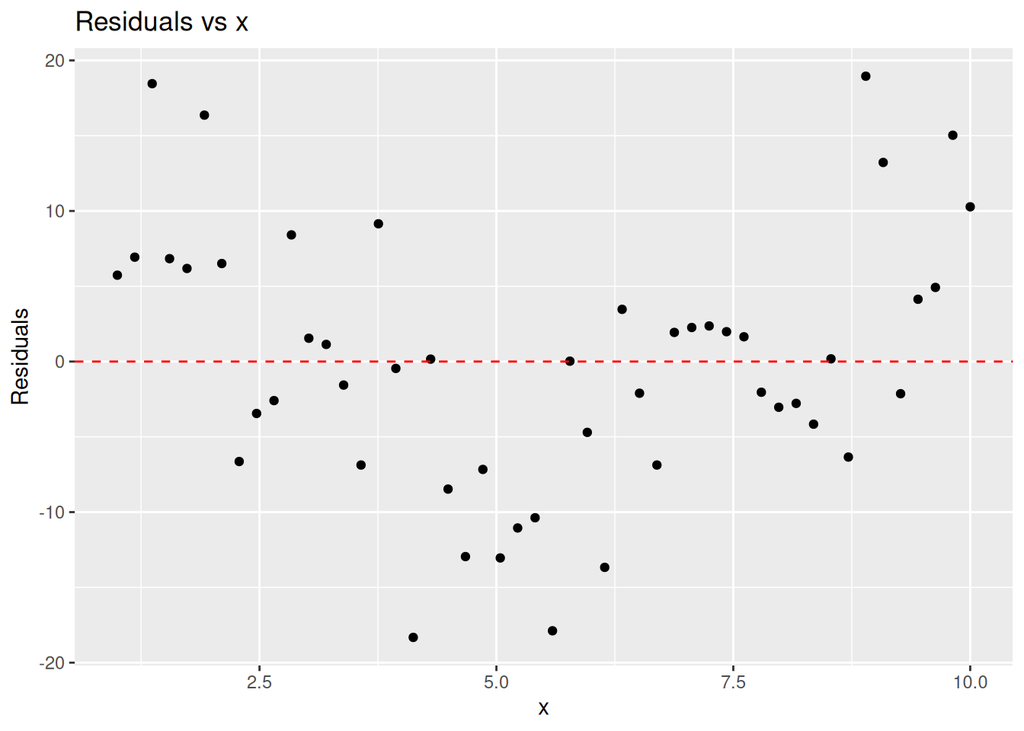

```r
# plot the residuals as a function of x
residuals = y - y_hat[1,]

g_res = ggplot(data=data, aes(x=x,y=residuals)) +
  geom_point() +
  geom_hline(yintercept=0, linetype="dashed", color="red") +
  labs(title="Residuals vs x", y="Residuals")
g_res
```

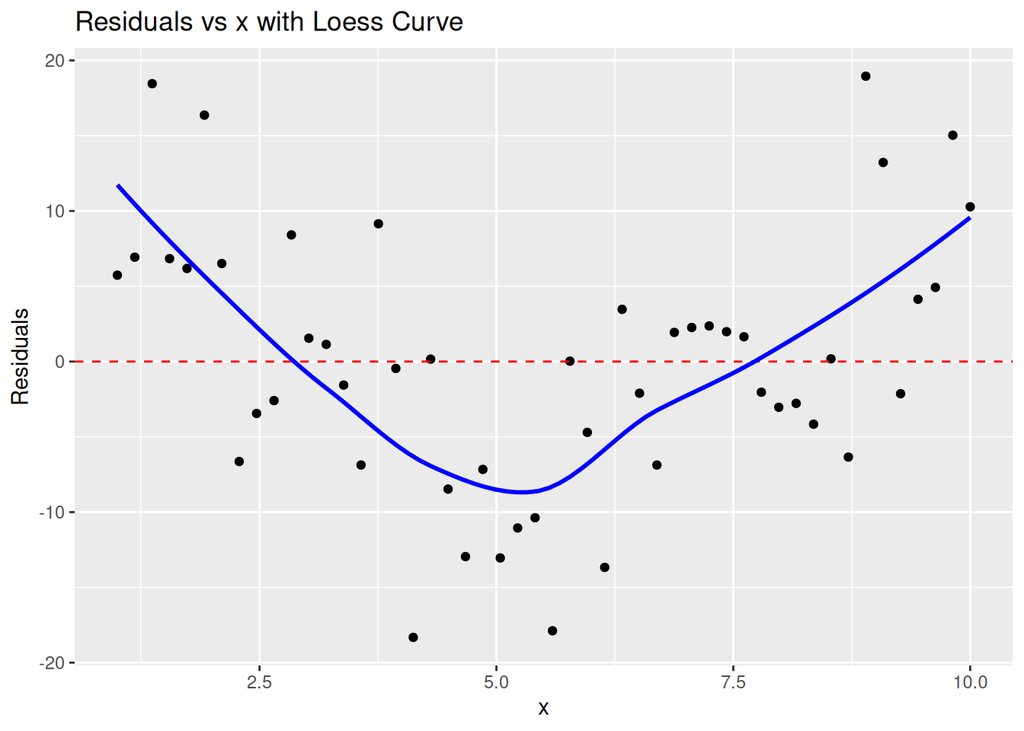

```r
# plot the residuals as a function of x
residuals = y - y_hat[1,]

g_res_loess = ggplot(data=data, aes(x=x,y=residuals)) +
  geom_point() +
  geom_hline(yintercept=0, linetype="dashed", color="red") +
  geom_smooth(method="loess", se=FALSE, color="blue") +
  labs(title="Residuals vs x with Loess Curve", y="Residuals")
g_res_loess
```

A few comments:

- The red line is the true function of $y$ and the black points are the data that we simulated;
- The blue line is the *expected value* (also called *fitted value*) of the predictive distribution at each point $x$, i.e. $\widehat{y} = E(y|x) = X\beta$;
- The shaded blue area corresponds to the $95\%$ predictive interval;
- The fit is not “good”, as the points at the two extremes are predicted to be lower than the true ones whereas those in the middle are predicted to be higher.

Thus, we would like to improve the fit of the model to the data by including further covariates. Since any nonlinear function can be approximated by a polynomial, we may consider

$$y = \beta_0+\beta_1x+\beta_2x^2+\beta_3x^3+\ldots$$

and truncate the summation at some degree $p$. We consider this approach and truncate at $p=2$, that is we include up to a squared transformation of the data $x$.

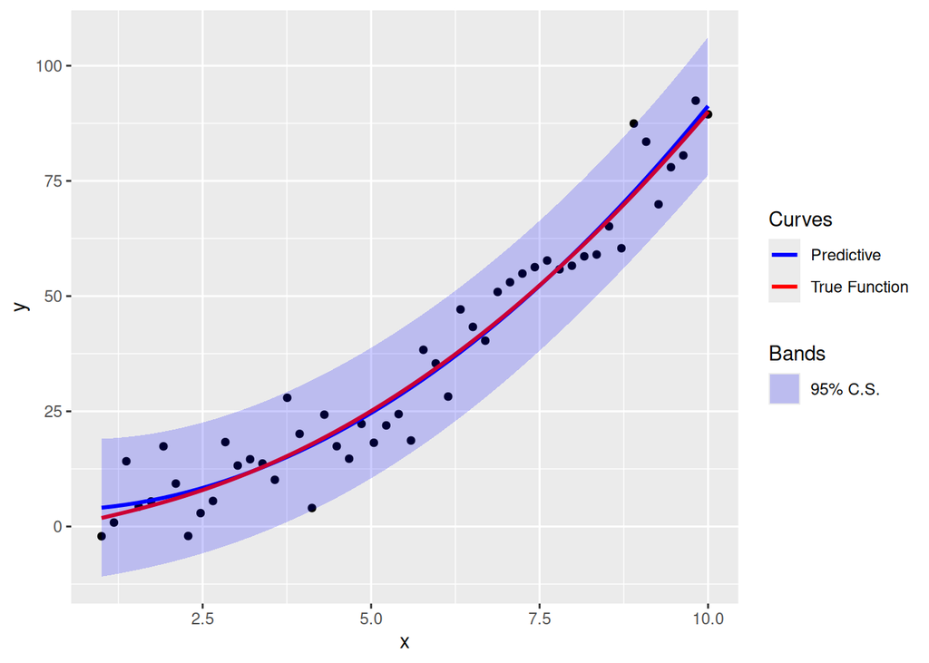

```r
# Construct the new design matrix
p = 3
X = matrix(c(rep(1,n),x,x^2),n,p)

# Prior hyperparameters (non-informative)
m0 = matrix(0,p,1)
S0 = diag(x=1000,p,p)

# Posterior parameters
SN = solve(solve(S0) + t(X) %*% X/sigma2)
mN = SN %*% (solve(S0) %*% m0 + t(X) %*% y/sigma2)

# Predictive distribution in the same points
y_hat = t(mN) %*% t(X)
sigma2_hat = array(0, n)
for(i in 1:n){
 sigma2_hat[i] = sigma2 + X[i,] %*% SN %*% X[i,]
}

# Plot
g_bayes = g1 +
  geom_line(aes(x=x,y=y_hat[1,], color="Predictive"), linewidth=1) +
  geom_function(aes(color="True Function"), fun = f, linewidth=1) +
  geom_ribbon(aes(x=x,y=y_hat[1,],
                  ymin=y_hat[1,]-1.96*sigma2_hat^0.5,
                  ymax=y_hat[1,]+1.96*sigma2_hat^0.5,
                  fill="95% C.S."), alpha=0.2) +
  scale_color_manual(name="Curves", values=c('blue','red')) +
  scale_fill_manual(name="Bands", values='blue')
g_bayes
```

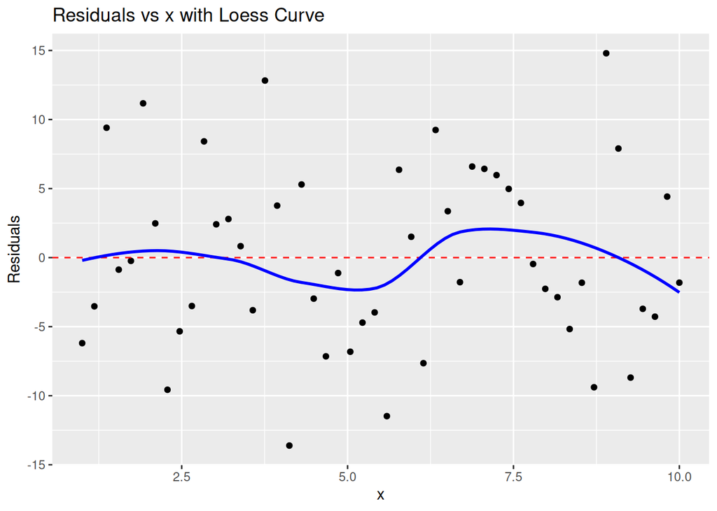

```r
# plot the residuals as a function of x
residuals = y - y_hat[1,]

g_res_loess = ggplot(data=data, aes(x=x,y=residuals)) +
  geom_point() +
  geom_hline(yintercept=0, linetype="dashed", color="red") +
  geom_smooth(method="loess", se=FALSE, color="blue") +
  labs(title="Residuals vs x with Loess Curve", y="Residuals")
g_res_loess
```

### *Example 2: estimate tooth length with a categorical predictor*

The `ToothGrowth` dataset records tooth growth in guinea pigs receiving one of two supplements and one of three dose levels of vitamin C. It contains $60$ observations on three variables:

- `len`: tooth length (response variable);
- `dose`: dose of vitamin C in mg/day (numeric predictor);
- `supp`: supplement type, either orange juice (`OJ`) or ascorbic acid (`VC`) (categorical predictor).

```r
# An easy-to-use package for Bayesian Linear Regression
library("BAS")

# Clear the workspace
rm(list=ls())

# Load dataset
data(ToothGrowth)
head(ToothGrowth)
```

```
##    len supp dose
## 1  4.2   VC  0.5
## 2 11.5   VC  0.5
## 3  7.3   VC  0.5
## 4  5.8   VC  0.5
## 5  6.4   VC  0.5
## 6 10.0   VC  0.5
```

This is automatically performed by the `lm()` function in R, which creates a design matrix with an intercept, the dummy variable for `supp` and the variable `dose`, similarly by BAS, which creates a design matrix with an intercept, the dummy variable for `supp` and the variable `dose` as well, provided that `supp` is stored in the dataframe as a factor variable. We can check that this is the case by looking at the structure of the dataset with `str()`.

```r
str(ToothGrowth)
```

```
## 'data.frame':    60 obs. of  3 variables:
##  $ len : num  4.2 11.5 7.3 5.8 6.4 10 11.2 11.2 5.2 7 ...
##  $ supp: Factor w/ 2 levels "OJ","VC": 2 2 2 2 2 2 2 2 2 2 ...
##  $ dose: num  0.5 0.5 0.5 0.5 0.5 0.5 0.5 0.5 0.5 0.5 ...
```

If `supp` wasn’t already a factor variable, we could have converted it into one with the command `ToothGrowth$supp = as.factor(ToothGrowth$supp)`.

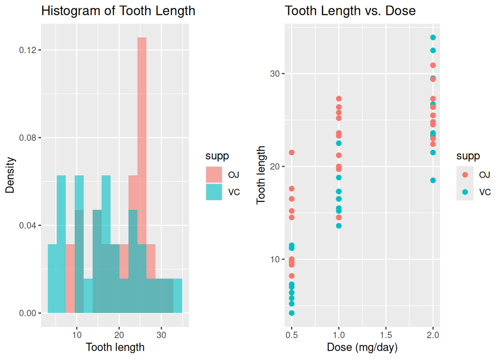

```r
# Visualize the data
hist = ggplot(data = ToothGrowth, aes(x = len, fill = supp)) +
  geom_histogram(aes(y = after_stat(density)),
                 bins = 15, alpha = 0.6, position = "identity") +
  ggtitle("Histogram of Tooth Length") +
  xlab("Tooth length") +
  ylab("Density")

scatter = ggplot(data = ToothGrowth, aes(x = dose, y = len, color = supp)) +
  geom_point(size = 2) +
  ggtitle("Tooth Length vs. Dose") +
  xlab("Dose (mg/day)") +
  ylab("Tooth length")

gridExtra::grid.arrange(hist, scatter, ncol = 2)
```

To make the role of the categorical variable explicit, it is useful to inspect the design matrix. By default, R uses treatment coding and takes the first level of the factor as the baseline.

```r
# Design matrix used by the regression
head(model.matrix(len ~ dose + supp, data = ToothGrowth))
```

```
##   (Intercept) dose suppVC
## 1           1  0.5      1
## 2           1  0.5      1
## 3           1  0.5      1
## 4           1  0.5      1
## 5           1  0.5      1
## 6           1  0.5      1
```

```r
tail(model.matrix(len ~ dose + supp, data = ToothGrowth))
```

```
##    (Intercept) dose suppVC
## 55           1    2      0
## 56           1    2      0
## 57           1    2      0
## 58           1    2      0
## 59           1    2      0
## 60           1    2      0
```

## 2. Frequentist linear regression

We consider a multiple linear regression model where $y_i$ denotes tooth length, $x_i$ denotes the vitamin C dose, and $z_i$ is an indicator variable taking value $1$ if the supplement is `VC` and $0$ if it is `OJ`. For unit $i$, the model is formulated as

$$y_i = \beta_0+ \beta_1 x_i + \beta_2 z_i + \epsilon_i, \qquad
i=1,\dots,n$$

where $\varepsilon_i\sim\mathscr{N}(0,\sigma^2)$. In the classical frequentist framework, estimation is carried out by ordinary least squares (OLS).

The function `lm` quickly performs the task.

```r
# Frequentist linear model
tooth.lm = lm(len ~ dose + supp, data = ToothGrowth)
summary(tooth.lm)
```

```
##
## Call:
## lm(formula = len ~ dose + supp, data = ToothGrowth)
##
## Residuals:
##    Min     1Q Median     3Q    Max
## -6.600 -3.700  0.373  2.116  8.800
##
## Coefficients:
##             Estimate Std. Error t value Pr(>|t|)
## (Intercept)   9.2725     1.2824   7.231 1.31e-09 ***
## dose          9.7636     0.8768  11.135 6.31e-16 ***
## suppVC       -3.7000     1.0936  -3.383   0.0013 **
## ---
## Signif. codes:  0 '***' 0.001 '**' 0.01 '*' 0.05 '.' 0.1 ' ' 1
##
## Residual standard error: 4.236 on 57 degrees of freedom
## Multiple R-squared:  0.7038, Adjusted R-squared:  0.6934
## F-statistic: 67.72 on 2 and 57 DF,  p-value: 8.716e-16
```

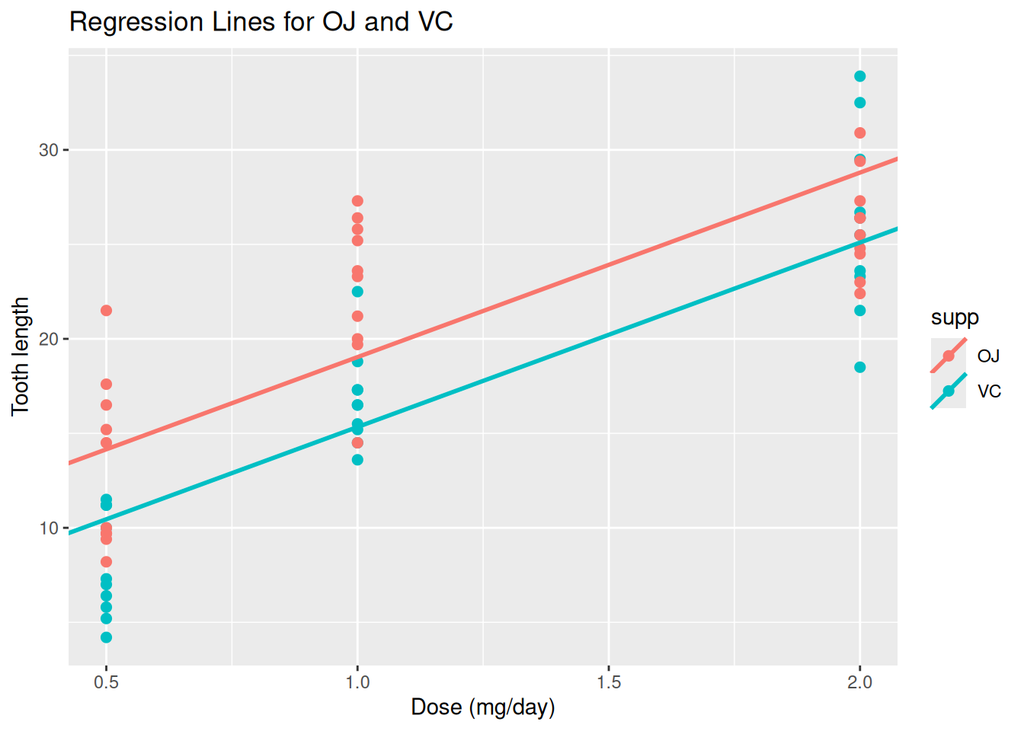

```r
# Visualize regression lines on the scatter plot using the fitted model

# Coefficients from the fitted model
coefs <- coef(tooth.lm)

# Data frame for the two regression lines
line_df <- data.frame(
  supp = c("OJ", "VC"),
  intercept = c(coefs[1], coefs[1] + coefs[3]),
  slope = c(coefs[2], coefs[2])
)

ggplot(data = ToothGrowth, aes(x = dose, y = len, color = supp)) +
  geom_point(size = 2) +
  geom_abline(
    data = line_df,
    aes(intercept = intercept, slope = slope, color = supp),
    linewidth = 1
  ) +
  xlab("Dose (mg/day)") +
  ylab("Tooth length") +
  ggtitle("Regression Lines for OJ and VC")
```

The classical approach allows us to compute confidence intervals, $t$-tests on the regression coefficients, and other diagnostics as shown in the output of `summary(tooth.lm)`.

## 3. Bayesian linear regression

From a modelling point of view, nothing changes when shifting from a frequentist to a Bayesian perspective. That is, the relationship between the dependent and independent variables is modelled in the same way:

$$y_i = \beta_0 + \beta_1 x_i + \beta_2 z_i + \epsilon_i, \quad
\varepsilon_i\sim\mathscr{N}(0,\sigma^2),$$

where $z_i$ is the dummy variable associated with the factor `supp`.

However, we change our method for estimating the parameters $\beta_0$, $\beta_1$, $\beta_2$, and $\sigma^2$, and for carrying out inference.

We assume a **non-informative** prior, i.e.

$$\begin{align*}
\pi\left(\, \beta \mid \sigma^2 \,\right) &\propto 1 \\
\pi\left(\sigma^2\right) &\propto \frac{1}{\sigma^2}
\end{align*}$$

Thus we apply Bayes’ rule to derive the joint posterior distribution after observing the data. Under the Gaussian linear model and the reference prior, the posterior distribution of $\sigma^2$ is an Inverse-Gamma,

$$\sigma^2 \mid \mathbf{y} \sim \mathscr{IG}\left(\frac{n-p-1}{2},
\frac{SSE}{2}\right),$$

where $SSE = \sum_{i=1}^{n}\widehat{\varepsilon}_{i}^2$ is the sum of squared errors and $p$ is the number of regressors excluding the intercept.

Conditional on $\sigma^2$, the posterior distribution of the coefficient vector is Gaussian,

$$\beta \mid \sigma^2, \mathbf{y} \sim \mathscr{N}\left(\widehat{\beta},
\sigma^2 (X^TX)^{-1}\right),$$

where $\widehat{\beta}$ is the OLS estimator. In other words, under the reference prior, the **posterior credible intervals are numerically equivalent to the confidence intervals from the frequentist OLS estimation**.

Since the credible intervals are numerically the same as the confidence intervals, we can use the `lm` function to obtain the OLS estimates and construct the credible intervals of the coefficients.

```r
output = summary(tooth.lm)$coef[, 1:2]
output
```

```
##              Estimate Std. Error
## (Intercept)  9.272500  1.2823649
## dose         9.763571  0.8768343
## suppVC      -3.700000  1.0936045
```

The `confint` function provides $95\%$ confidence intervals. Under the reference prior, they are equivalent to the $95\%$ credible intervals. The code below extracts them and relabels the output as the Bayesian results.

```r
out = cbind(output, confint(tooth.lm))
colnames(out) = c("posterior mean", "posterior std", "2.5", "97.5")
round(out, 3)
```

```
##             posterior mean posterior std    2.5   97.5
## (Intercept)          9.272         1.282  6.705 11.840
## dose                 9.764         0.877  8.008 11.519
## suppVC              -3.700         1.094 -5.890 -1.510
```

For example, the coefficient on `dose` measures the expected increase in tooth length for an additional 1 mg/day of vitamin C, holding the supplement type fixed. The coefficient on `suppVC` measures the expected difference between `VC` and the baseline category `OJ`, holding the dose fixed.

To obtain fitted values and intervals, we compute predictions on a grid of doses for both supplement types.

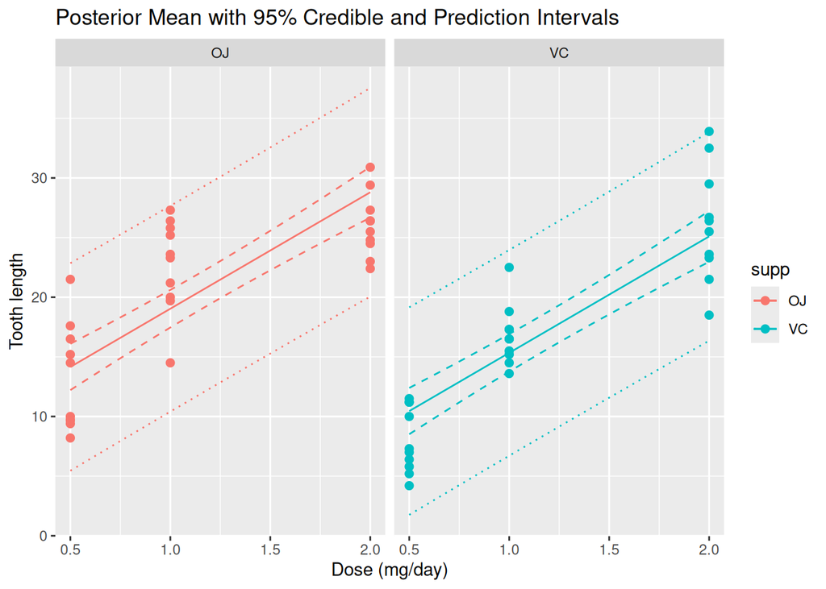

```r
newdata = expand.grid(
  dose = seq(min(ToothGrowth$dose), max(ToothGrowth$dose), length.out = 100),
  supp = levels(ToothGrowth$supp)
)

# Posterior mean and 95% credible intervals for the mean
ymean = data.frame(
  newdata,
  predict(tooth.lm,
          newdata = newdata,
          interval = "confidence",
          level = 0.95)
)

# Posterior prediction intervals
ypred = data.frame(
  newdata,
  predict(tooth.lm,
          newdata = newdata,
          interval = "prediction",
          level = 0.95)
)

# Plot
ggplot(ToothGrowth, aes(x = dose, y = len, color = supp)) +
  geom_point(size = 2) +
  geom_line(data = ymean, aes(y = fit)) +
  geom_line(data = ymean, aes(y = lwr), linetype = 2) +
  geom_line(data = ymean, aes(y = upr), linetype = 2) +
  geom_line(data = ypred, aes(y = lwr), linetype = 3) +
  geom_line(data = ypred, aes(y = upr), linetype = 3) +
  facet_wrap(~ supp) +
  xlab("Dose (mg/day)") + ylab("Tooth length") +
  ggtitle("Posterior Mean with 95% Credible and Prediction Intervals")
```

### Exercise 1

The `mtcars` dataset is a classic in R that provides various automobile attributes for different car models. It contains $32$ observations on $11$ variables.

Two of the relevant variables for this exercise are:

- `mpg`: Miles per gallon — a measure of fuel efficiency.
- `hp`: Gross horsepower — a measure of engine power.

We aim to explore how horsepower affects fuel efficiency by fitting a simple linear regression.

1. Fit a linear regression model with `mpg` as the dependent variable and `hp` as the independent variable.
2. Plot the actual data points using the `plot()` function.
3. Add the fitted regression line using `abline()`.
4. Add 95% confidence and prediction bands.

```r
# Load the dataset
data(mtcars)

# write here your code
```

### *Example 3: Zellner’s g-priors*

Now that we have warmed up, we consider more than a single explanatory variable. In the remainder, we will denote $X$ as a $n\times (p+1)$ matrix.

The prior density reads

$$\beta\mid\sigma^2\sim\mathscr N_{k}\left(0,g \, \sigma^2
(X^{\prime}X)^{-1} \right)\\
(\beta_0,\sigma^2)\sim\pi(\beta_0,\sigma^2)=\sigma^{-2}$$

which is thus decomposed as a (conditional) Gaussian prior for $\beta$ and an improper (Jeffreys) prior for $(\beta_0,\sigma^2)$.

The hyperparameter $g>0$ can be interpreted as describing the weight given to the data compared to prior knowledge. For instance, setting $g = n$ gives the prior the same weight as one observation of the sample, thus corresponding to a non-informative prior.

Now, we estimate a number of model specifications with the function `bas.lm` using Zellner’s $g$-prior and the predictors `dose` and `supp`. Among the inputs, we set `modelprior=Bernoulli(1)` to include all the covariates in the model with probability 1 (otherwise the routine also fits submodels, which we will discuss in the next lecture) and we use several values of $g = (0.001,0.01,0.1,1,10,n)$.

Notice that in `bas.lm` we need to specify the value of $g$ with the argument `alpha`.

```r
library(latex2exp)
library("BAS")

tg = ToothGrowth
output = data.frame(dose=numeric(0), y_hat=numeric(0), alpha=numeric(0), supp=character(0))

# Calculate centered dose
X = tg$dose - mean(tg$dose)
n = length(X)

newdata = expand.grid(
  dose = seq(min(tg$dose), max(tg$dose), length.out = 100),
  supp = levels(tg$supp)
)
newdata$dose_c = newdata$dose - mean(tg$dose)

for(alpha in c(0.001,0.01,0.1,1,10,n)){

  # Fit Bayesian linear model using g-prior and the current value of alpha
  tooth.blm = bas.lm(len ~ dose_c + supp,
                     data = transform(tg, dose_c = X),
                     prior = "g-prior", alpha = alpha,
                     modelprior = Bernoulli(1))

  # Predict tooth length on the grid of doses and supplement types
  pred = predict(tooth.blm, newdata = newdata)

  # Append the results to the output data frame
  output = rbind(output,
                 data.frame(dose = newdata$dose,
                            supp = newdata$supp,
                            y_hat = pred$fit,
                            alpha = alpha))
}

output$alpha = as.factor(output$alpha)

# Summary
summary(tooth.blm)
```

```
##           P(B != 0 | Y)  model 1
## Intercept             1  1.00000
## dose_c                1  1.00000
## suppVC                1  1.00000
## BF                   NA  1.00000
## PostProbs            NA  1.00000
## R2                   NA  0.70380
## dim                  NA  3.00000
## logmarg              NA 30.65481
```

When $g$ is small, the posterior predicted values are similar to a model where the prior strongly shrinks the coefficients toward zero. As $g$ increases, the posterior predictions become more and more similar to the outcome of a model using a non-informative prior.

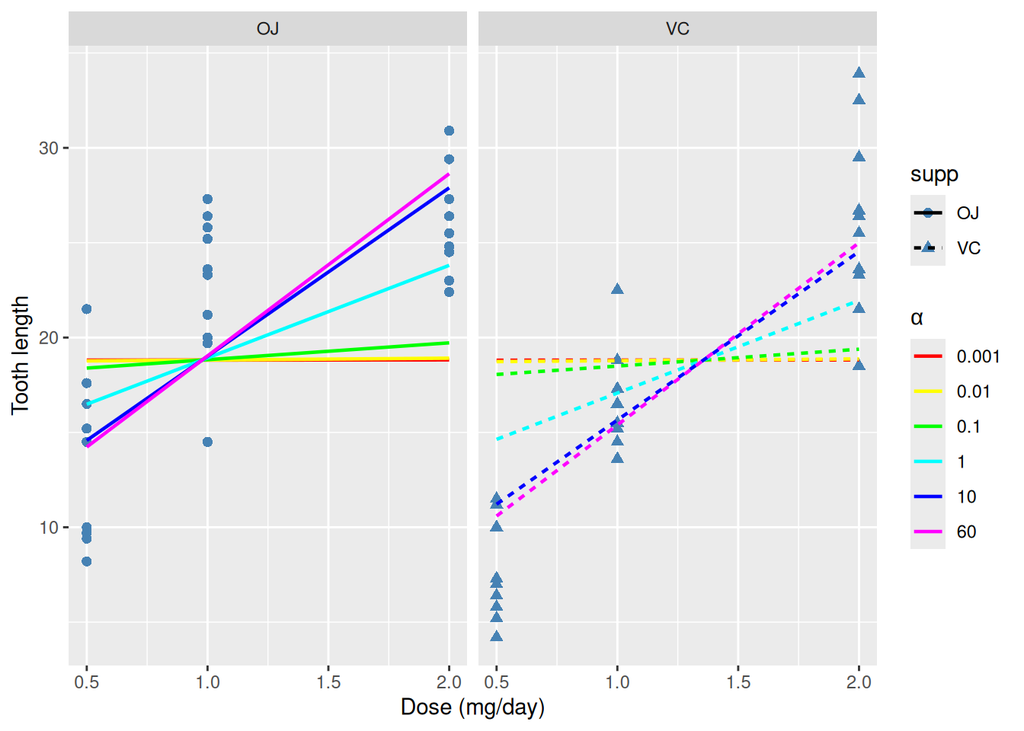

```r
# Plot
plot1 = ggplot(data = tg, aes(x = dose, y = len)) +
  geom_point(aes(shape = supp), color = "steelblue", size = 2) +
  geom_line(data = output,
            aes(x = dose, y = y_hat,
                group = interaction(alpha, supp),
                color = alpha,
                linetype = supp), linewidth = 0.8) +
  facet_wrap(~ supp) +
  xlab("Dose (mg/day)") + ylab("Tooth length") +
  scale_colour_manual(values = rainbow(length(levels(output$alpha))),
                      name = TeX("$\\alpha$"))
plot1
```

In general, we can allow the prior location for $\beta$ to be some nonzero value. However, there is no direct argument to set a nonzero prior mean for the intercept in `bas.lm`. In this case, you can use a workaround and center the outcome variable manually before fitting the model.

An alternative model is the one in which we consider the interaction between `dose` and `supp`, which allows the effect of the dose to differ across the two supplement types. This is done by including the term `dose:supp` in the formula of the regression model. Let’s consider the model with $g=n$ and compare the results with the previous one without interaction.

```r
# Design matrix used by the regression
head(model.matrix(len ~ dose * supp, data = ToothGrowth))
```

```
##   (Intercept) dose suppVC dose:suppVC
## 1           1  0.5      1         0.5
## 2           1  0.5      1         0.5
## 3           1  0.5      1         0.5
## 4           1  0.5      1         0.5
## 5           1  0.5      1         0.5
## 6           1  0.5      1         0.5
```

```r
tail(model.matrix(len ~ dose * supp, data = ToothGrowth))
```

```
##    (Intercept) dose suppVC dose:suppVC
## 55           1    2      0           0
## 56           1    2      0           0
## 57           1    2      0           0
## 58           1    2      0           0
## 59           1    2      0           0
## 60           1    2      0           0
```

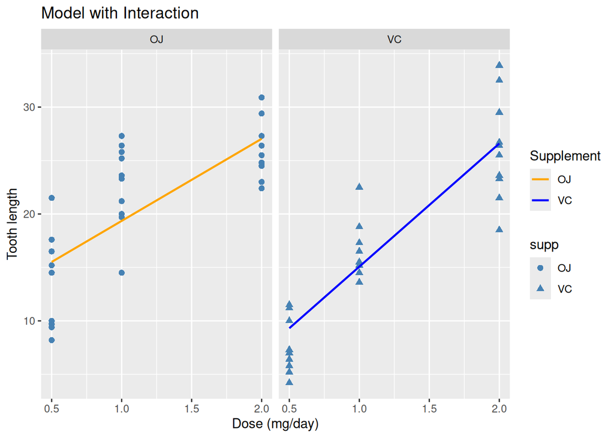

```r
alpha = n

# Fit the model with interaction
tooth.bl_interaction = bas.lm(len ~ dose * supp,
                              data = ToothGrowth,
                              prior = "g-prior",
                              alpha = alpha,
                              modelprior = Bernoulli(1))

# Predict tooth length on the grid of doses and supplement types
pred_interaction = predict(tooth.bl_interaction, newdata = newdata)

# Build a data frame for plotting
plot_interaction = data.frame(
  dose = newdata$dose,
  supp = newdata$supp,
  fit  = as.numeric(pred_interaction$fit)
)

# Plot
ggplot(data = ToothGrowth, aes(x = dose, y = len)) +
  geom_point(aes(shape = supp), color = "steelblue", size = 2) +
  geom_line(data = plot_interaction,
            aes(x = dose, y = fit, color = supp, group = supp),
            linewidth = 0.8) +
  facet_wrap(~ supp) +
  xlab("Dose (mg/day)") +
  ylab("Tooth length") +
  ggtitle("Model with Interaction") +
  scale_color_manual(values = c("OJ" = "orange", "VC" = "blue"),
                     name = "Supplement")
```

As you can see the estimated slopes are different, we will discuss next lecture how to formally compare the two models and test whether the interaction term is significant or not. Notice that we cannot simply compare the performance on the data itself, because the second model is more general and thus will always fit the data better. We need to use a criterion that accounts for the complexity of the model (in an ideal world, Bayes Factor…).

### Exercise 2

Consider now the `swiss` dataset, which contains socio-economic indicators for $47$ French-speaking provinces of Switzerland.

We focus on the following variables:

- `Fertility`: a measure of fertility (response variable);
- `Education`: percentage of draftees receiving education beyond primary school;
- `Catholic`: percentage of Catholics in the province.

We would like to study whether the effect of education on fertility changes with the proportion of Catholics by comparing an additive model and a model with interaction under Zellner’s $g$-prior.

1. Fit the models `Fertility ~ Education + Catholic` and `Fertility ~ Education * Catholic` using `bas.lm` with `prior = "g-prior"` and `alpha = n`.
2. Build a grid of values for `Education`, keeping `Catholic` fixed at a few representative levels (for example, low, medium, and high).
3. Compute the fitted values under both models.
4. Produce suitable plots to compare the two models.
5. Briefly comment on how the interaction term changes the interpretation of the relationship between education and fertility.

```r
# Load the dataset
data(swiss)

# write here your code
summary(swiss)
```

```
##    Fertility      Agriculture     Examination      Education
##  Min.   :35.00   Min.   : 1.20   Min.   : 3.00   Min.   : 1.00
##  1st Qu.:64.70   1st Qu.:35.90   1st Qu.:12.00   1st Qu.: 6.00
##  Median :70.40   Median :54.10   Median :16.00   Median : 8.00
##  Mean   :70.14   Mean   :50.66   Mean   :16.49   Mean   :10.98
##  3rd Qu.:78.45   3rd Qu.:67.65   3rd Qu.:22.00   3rd Qu.:12.00
##  Max.   :92.50   Max.   :89.70   Max.   :37.00   Max.   :53.00
##     Catholic       Infant.Mortality
##  Min.   :  2.150   Min.   :10.80
##  1st Qu.:  5.195   1st Qu.:18.15
##  Median : 15.140   Median :20.00
##  Mean   : 41.144   Mean   :19.94
##  3rd Qu.: 93.125   3rd Qu.:21.70
##  Max.   :100.000   Max.   :26.60
```